# Final_Project_Draft

# Realtionship between sleep efficiency and strongly correlated variables

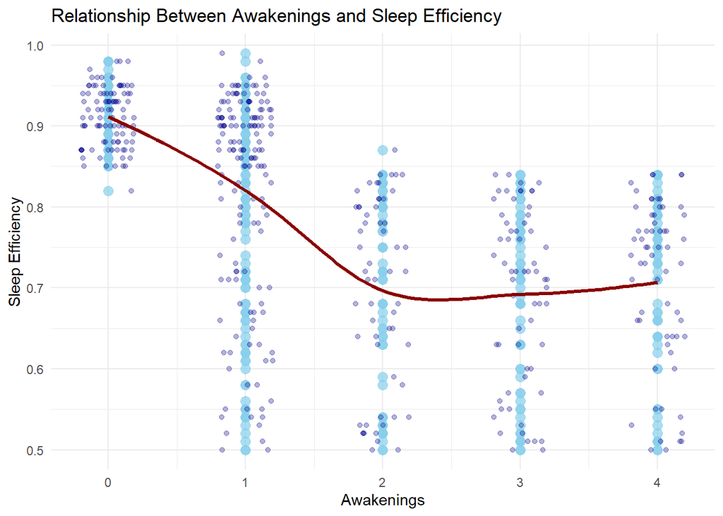

```r
ggplot(data, aes(x = Awakenings, y = Sleep.efficiency)) +
  geom_point(alpha = 0.7, size = 3, color = "skyblue") +
  geom_jitter(width = 0.2, height = 0, color = "darkblue", alpha = 0.3) +
  geom_smooth(method = "loess", color = "darkred", size = 1.2, se = FALSE) +
  labs(
    title = "Relationship Between Awakenings and Sleep Efficiency",
    x = "Awakenings",
    y = "Sleep Efficiency"
  ) +
  theme_minimal()
```

```r
head(data)
```

```
##   ID Age Gender          Bedtime      Wakeup.time Sleep.duration
## 1  1  65      0 06-03-2021 01:00 06-03-2021 07:00            6.0
## 2  2  69      1 05-12-2021 02:00 05-12-2021 09:00            7.0
## 3  3  40      0 25-05-2021 21:30 25-05-2021 05:30            8.0
## 4  4  40      0 03-11-2021 02:30 03-11-2021 08:30            6.0
## 5  5  57      1 13-03-2021 01:00 13-03-2021 09:00            8.0
## 6  6  36      0 01-07-2021 21:00 01-07-2021 04:30            7.5
##   Sleep.efficiency REM.sleep.percentage Deep.sleep.percentage
## 1             0.88                   18                    70
## 2             0.66                   19                    28
## 3             0.89                   20                    70
## 4             0.51                   23                    25
## 5             0.76                   27                    55
## 6             0.90                   23                    60
##   Light.sleep.percentage Awakenings Caffeine.consumption Alcohol.consumption
## 1                     12          0                    0                   0
## 2                     53          3                    0                   3
## 3                     10          1                    0                   0
## 4                     52          3                   50                   5
## 5                     18          3                    0                   3
## 6                     17          0                   25                   0
##   Smoking.status Exercise.frequency
## 1              1                  3
## 2              1                  3
## 3              0                  3
## 4              1                  1
## 5              0                  3
## 6              0                  1
```

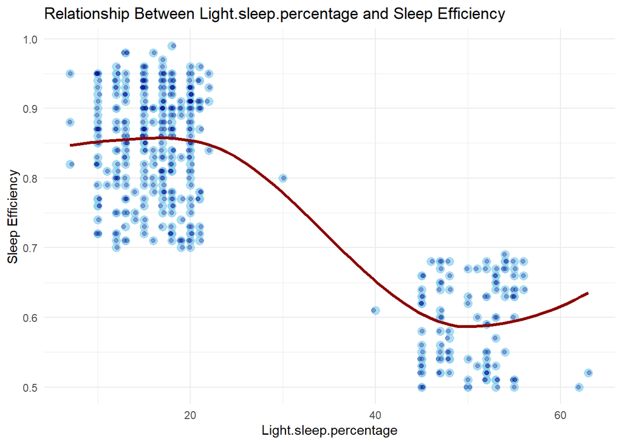

```r
ggplot(data, aes(x = Light.sleep.percentage, y = Sleep.efficiency)) +
  geom_point(alpha = 0.7, size = 3, color = "skyblue") +
  geom_jitter(width = 0.2, height = 0, color = "darkblue", alpha = 0.3) +
  geom_smooth(method = "loess", color = "darkred", size = 1.2, se = FALSE) +
  labs(
    title = "Relationship Between Light.sleep.percentage and Sleep Efficiency",
    x = "Light.sleep.percentage",
    y = "Sleep Efficiency"
  ) +
  theme_minimal()
```

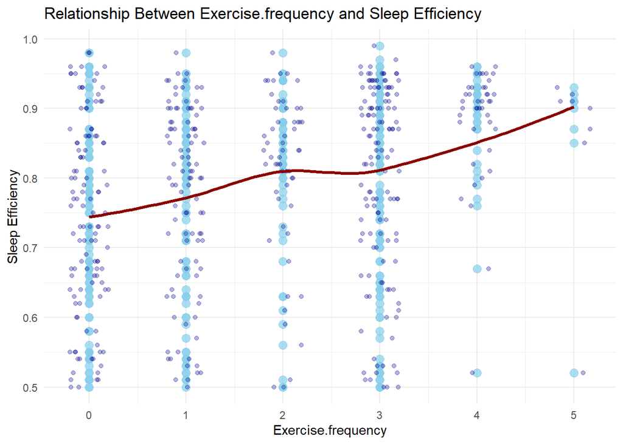

```r
ggplot(data, aes(x = Exercise.frequency, y = Sleep.efficiency)) +
  geom_point(alpha = 0.7, size = 3, color = "skyblue") +
  geom_jitter(width = 0.2, height = 0, color = "darkblue", alpha = 0.3) +
  geom_smooth(method = "loess", color = "darkred", size = 1.2, se = FALSE) +
  labs(
    title = "Relationship Between Exercise.frequency and Sleep Efficiency",
    x = "Exercise.frequency",
    y = "Sleep Efficiency"
  ) +
  theme_minimal()
```

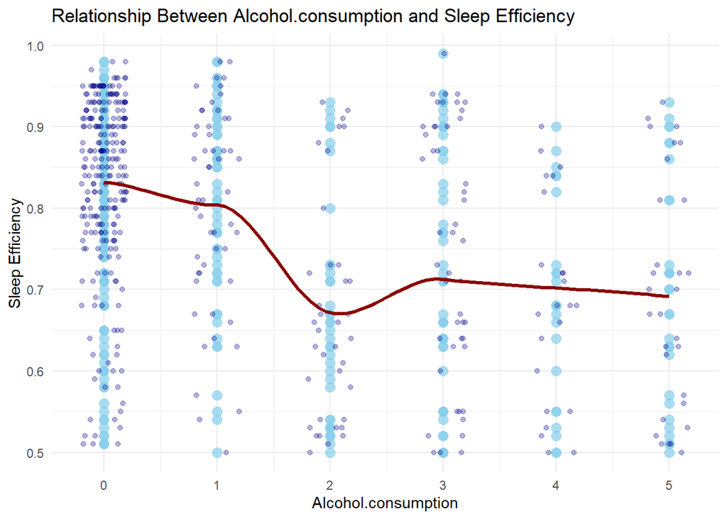

```r
ggplot(data, aes(x = Alcohol.consumption, y = Sleep.efficiency)) +
  geom_point(alpha = 0.7, size = 3, color = "skyblue") +
  geom_jitter(width = 0.2, height = 0, color = "darkblue", alpha = 0.3) +
  geom_smooth(method = "loess", color = "darkred", size = 1.2, se = FALSE) +
  labs(
    title = "Relationship Between Alcohol.consumption and Sleep Efficiency",
    x = "Alcohol.consumption",
    y = "Sleep Efficiency"
  ) +
  theme_minimal()
```

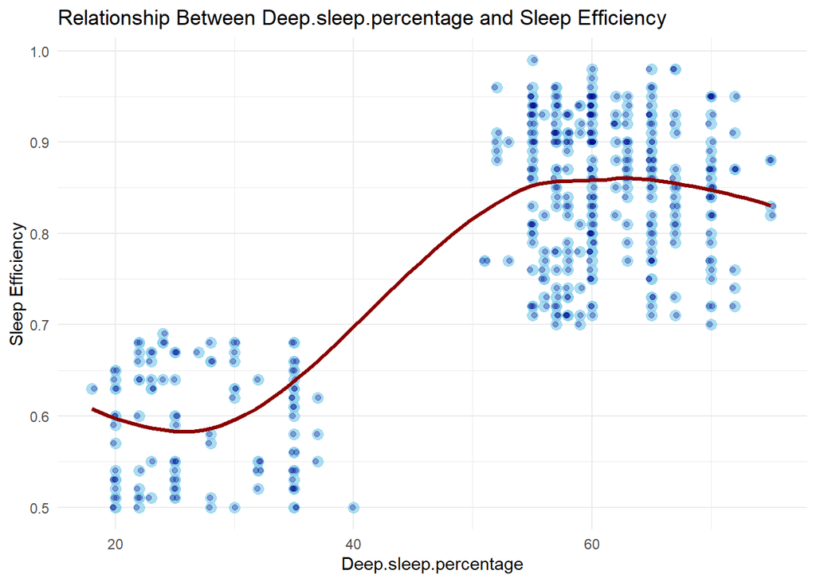

```r
ggplot(data, aes(x = Deep.sleep.percentage, y = Sleep.efficiency)) +
  geom_point(alpha = 0.7, size = 3, color = "skyblue") +
  geom_jitter(width = 0.2, height = 0, color = "darkblue", alpha = 0.3) +
  geom_smooth(method = "loess", color = "darkred", size = 1.2, se = FALSE) +
  labs(
    title = "Relationship Between Deep.sleep.percentage and Sleep Efficiency",
    x = "Deep.sleep.percentage",
    y = "Sleep Efficiency"
  ) +
  theme_minimal()
```

#Trivariate Analysis Sleep efficiency vs Duration wrt gender

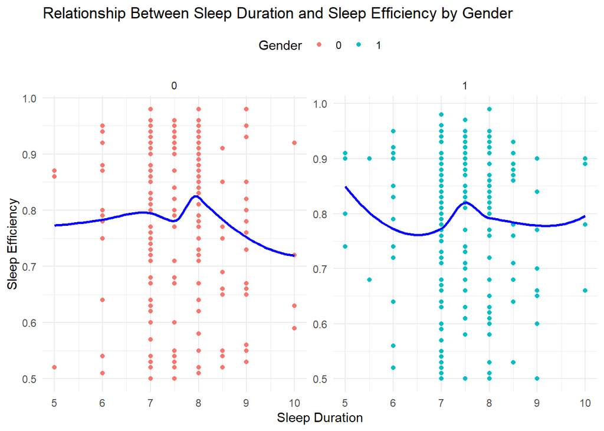

```r
# Beautified code
library(ggplot2)

data$age_bins <- cut(data$Age, breaks = seq(0, 100, by = 20), right = FALSE)

ggplot(data, aes(x = Sleep.duration, y = Sleep.efficiency, color = Gender)) +
  geom_point() +
  geom_smooth(method = "loess", se = FALSE, size = 1, linetype = 'solid', color = 'blue') +
  labs(x = "Sleep Duration", y = "Sleep Efficiency") +
  ggtitle("Relationship Between Sleep Duration and Sleep Efficiency by Gender") +  # Add the title here
  theme_minimal() +
  theme(legend.position = "top") +
  facet_wrap(~ Gender, scales = "free")
```

# Light Sleep vs Efficiency Wrt Gender

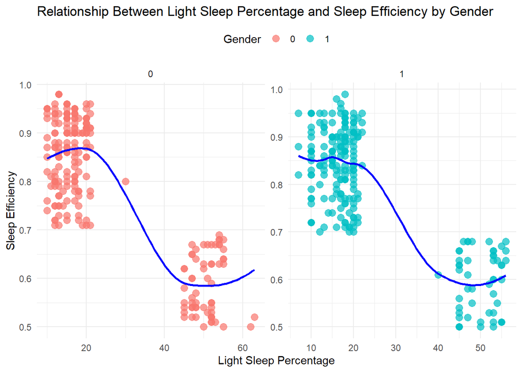

```r
library(ggplot2)

ggplot(data, aes(x = Light.sleep.percentage, y = Sleep.efficiency, color = Gender)) +
  geom_point(size = 3, alpha = 0.7) +
  geom_smooth(method = "loess", se = FALSE, size = 1, linetype = 'solid', color = 'blue') +
  labs(x = "Light Sleep Percentage", y = "Sleep Efficiency") +
  ggtitle("Relationship Between Light Sleep Percentage and Sleep Efficiency by Gender") +  # Add the title here
  theme_minimal() +
  theme(legend.position = "top") +
  facet_wrap(~ Gender, scales = "free")
```

```r
data$Smoking.binary <- as.integer(data$Smoking.status == "1")
```

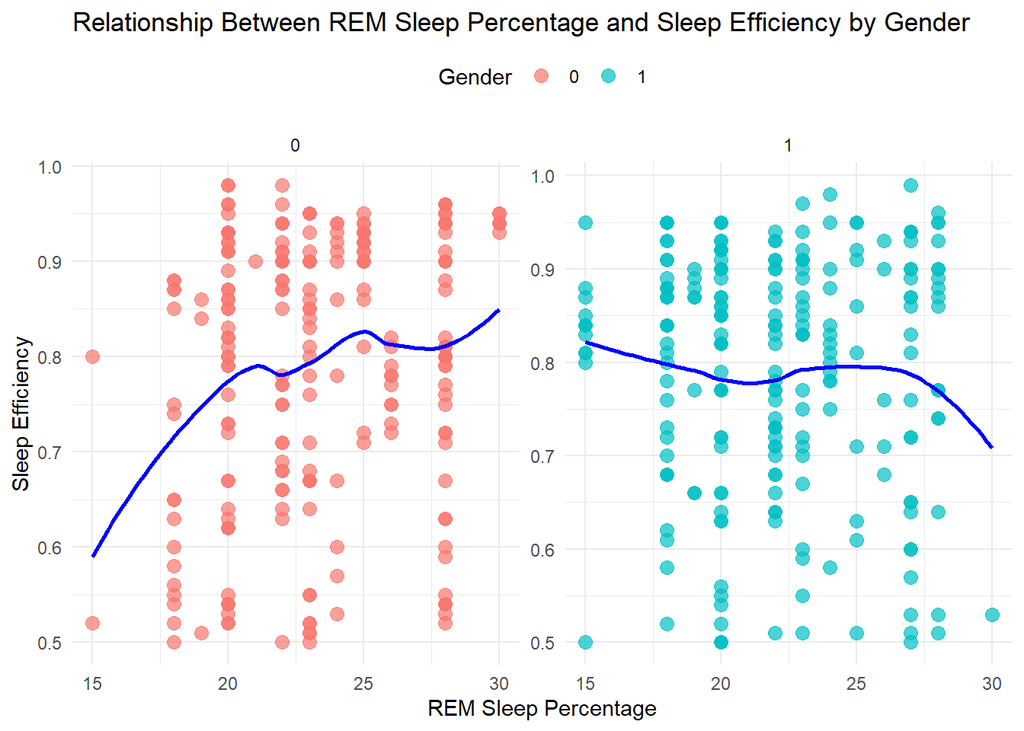

```r
library(ggplot2)

ggplot(data, aes(x = REM.sleep.percentage, y = Sleep.efficiency, color = Gender)) +
  geom_point(size = 3, alpha = 0.7) +
  geom_smooth(method = "loess", se = FALSE, size = 1, linetype = 'solid', color = 'blue') +
  labs(x = "REM Sleep Percentage", y = "Sleep Efficiency") +
  ggtitle("Relationship Between REM Sleep Percentage and Sleep Efficiency by Gender") +  # Add the title here
  theme_minimal() +
  theme(legend.position = "top") +
  facet_wrap(~ Gender, scales = "free")
```

# Awakenings vs Caffeine Consumption keeping sleep efficiency as the variable

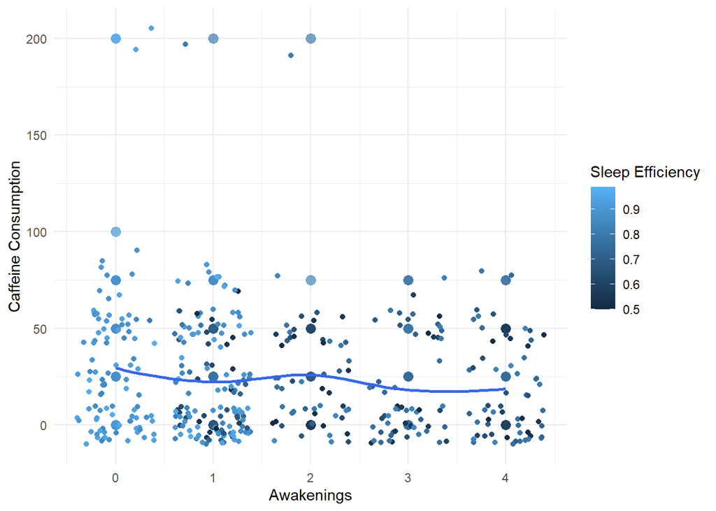

```r
library(ggplot2)

ggplot(data, aes(x = Awakenings, y = Caffeine.consumption, color = Sleep.efficiency)) +
  geom_point(size = 3, alpha = 0.7) +
  geom_jitter() +
  geom_smooth(method = "loess", se = FALSE, size = 1, linetype = 'solid') +
  xlab("Awakenings") +
  ylab("Caffeine Consumption") +
  labs(color = "Sleep Efficiency") +
  theme_minimal()
```

# Trying another plot for the above graph

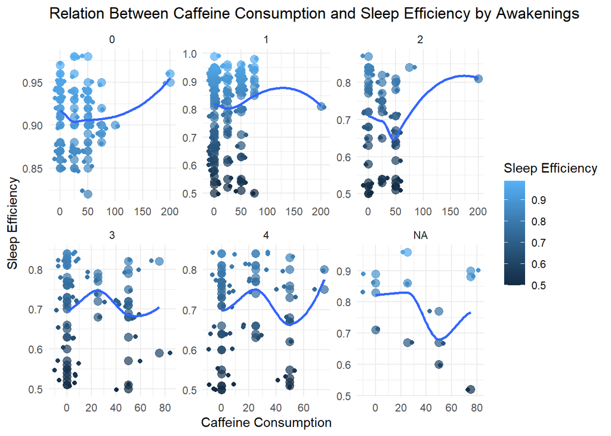

```r
library(ggplot2)

ggplot(data, aes(x = Caffeine.consumption, y = Sleep.efficiency, color = Sleep.efficiency)) +
  geom_point(size = 3, alpha = 0.7) +
  geom_jitter() +
  geom_smooth(method = "loess", se = FALSE, size = 1, linetype = 'solid') +
  xlab("Caffeine Consumption") +
  ylab("Sleep Efficiency") +
  labs(color = "Sleep Efficiency") +
  ggtitle("Relation Between Caffeine Consumption and Sleep Efficiency by Awakenings") +  # Add the title here
  theme_minimal() +
  facet_wrap(~ Awakenings, scales = "free")
```

##################################################################################################################################### # Smoking vs Caffeine consumption

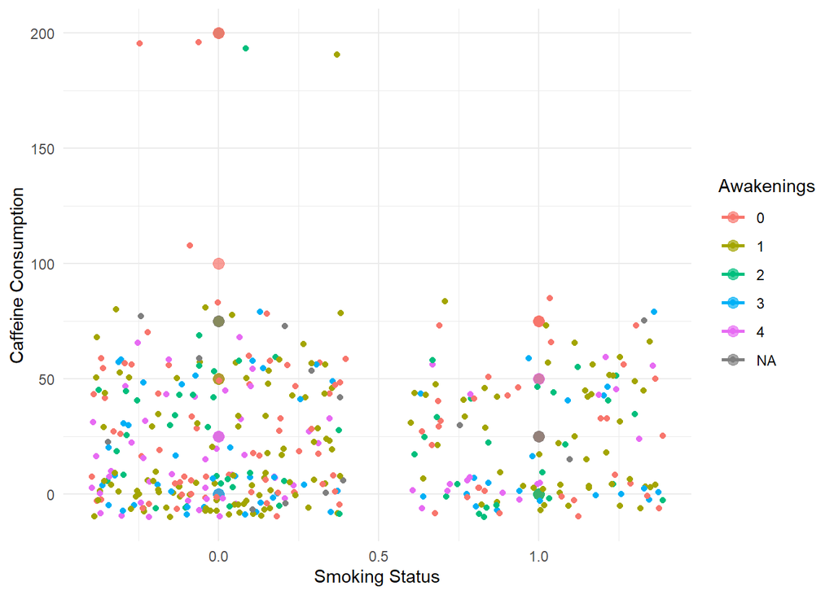

```r
library(ggplot2)

ggplot(data, aes(x = Smoking.status, y = Caffeine.consumption, color = factor(Awakenings))) +
  geom_point(size = 3, alpha = 0.7) +
  geom_jitter() +
  geom_smooth(method = "loess", se = FALSE, size = 1, linetype = 'solid') +
  xlab("Smoking Status") +
  ylab("Caffeine Consumption") +
  labs(color = "Awakenings") +
  theme_minimal()
```

#Trying new plot

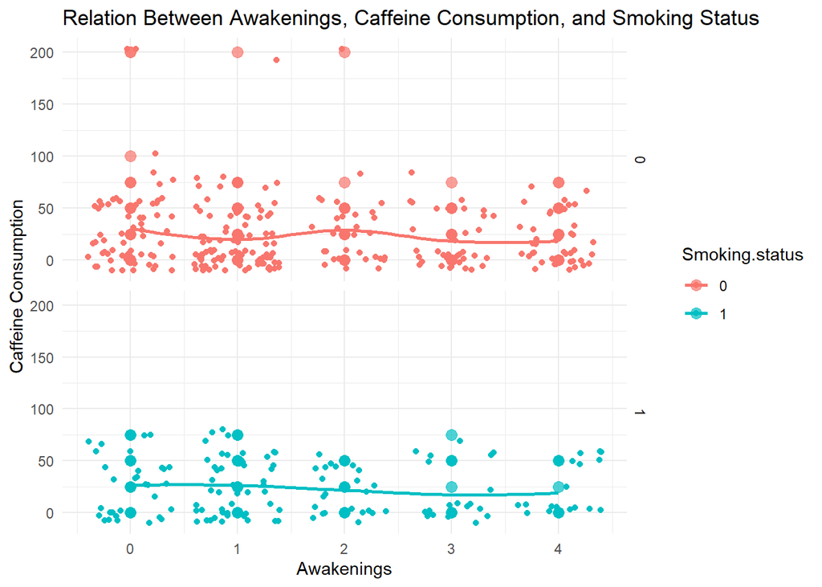

```r
library(ggplot2)

ggplot(data, aes(x = Awakenings, y = Caffeine.consumption, color = factor(Smoking.status))) +
  geom_point(size = 3, alpha = 0.7) +
  geom_jitter() +
  geom_smooth(method = "loess", se = FALSE, size = 1, linetype = 'solid') +
  xlab("Awakenings") +
  ylab("Caffeine Consumption") +
  labs(color = "Smoking.status") +
  theme_minimal() +
  facet_grid(Smoking.status ~ ., scales = "free_x") +  # Facet by Smoking Status on the x-axis and Awakenings on the y-axis
  ggtitle("Relation Between Awakenings, Caffeine Consumption, and Smoking Status")
```

This code creates a new variable Smoking.Caffine.Alcohol in the data dataframe based on certain conditions. Here’s an explanation of the code:

data$Smoking.status == "Yes": Checks if the value in the 'Smoking.status' column is "Yes." data$Caffeine.consumption != ‘NA’ & data$Caffeine.consumption > 1: Checks if the 'Caffeine.consumption' column is not 'NA' and its value is greater than 1. data$Alcohol.consumption != ‘NA’ & data$Alcohol.consumption > 1: Checks if the ‘Alcohol.consumption’ column is not ‘NA’ and its value is greater than 1.

```r
data$Smoking.Caffine.Alcohol = ifelse(data$Smoking.status == "Yes" | (data$Caffeine.consumption != 'NA' & data$Caffeine.consumption > 1) | (data$Alcohol.consumption != 'NA' & data$Alcohol.consumption > 1) , 1, 0)
```

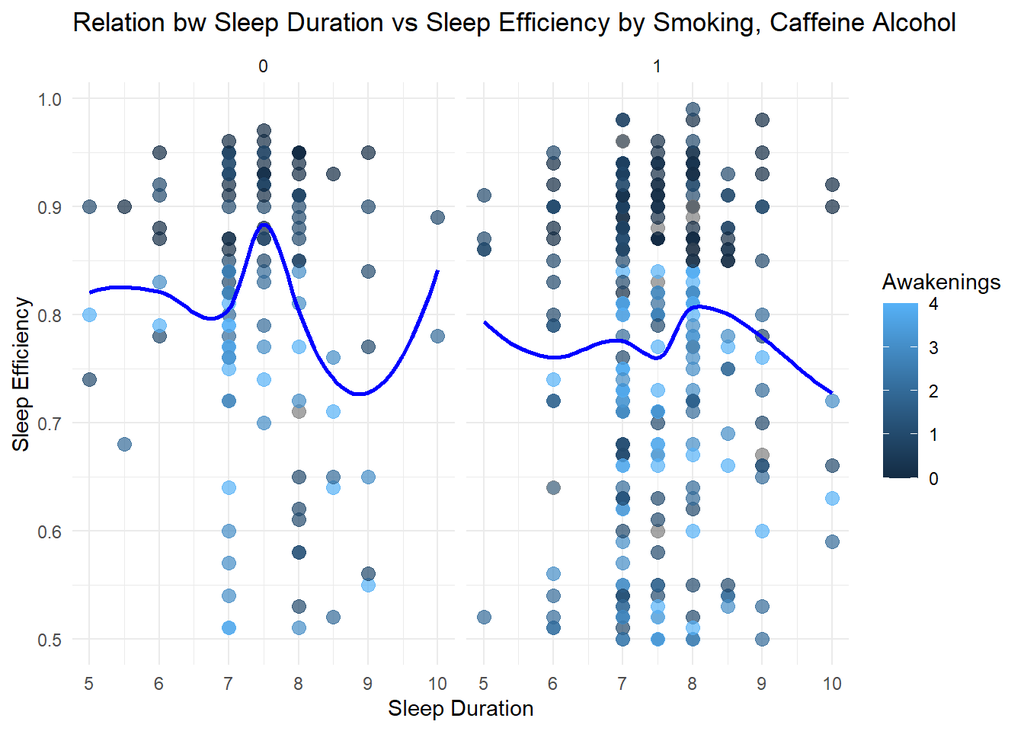

```r
library(ggplot2)
library(dplyr)

# Remove NA values from Smoking.Caffine.Alcohol
data_filtered <- data %>%
  filter(!is.na(Smoking.Caffine.Alcohol))

ggplot(data_filtered, aes(x = Sleep.duration, y = Sleep.efficiency, color = Awakenings)) +
  geom_point(size = 3, alpha = 0.7) +
  geom_smooth(method = "loess", se = FALSE, size = 1, linetype = 'solid', color = 'blue') +
  labs(
    title = "Relation bw Sleep Duration vs Sleep Efficiency by Smoking, Caffeine Alcohol",
    x = "Sleep Duration",
    y = "Sleep Efficiency",
    color = "Awakenings"
  ) +
  theme_minimal() +
  facet_grid(. ~ Smoking.Caffine.Alcohol, scales = "free")
```

#############################################################################################################################################

[figure not shown]

```r
# Assuming 'Gender' is a factor variable in your data
data$Gender <- factor(data$Gender)

# Load necessary library
library(vcd)

# Create a mosaic plot using vcd package with custom styling
mosaic_plot <- mosaic(~ Sleep.efficiency + Gender, data,
                      gp = gpar(col = "blue", fontsize = 12),
                      main = "Mosaic Plot of Sleep Efficiency by Gender")
```

```r
print(mosaic_plot)
```

```
##                  Gender  0  1
## Sleep.efficiency
## 0.5                      3  5
## 0.51                     3  5
## 0.52                     7  2
## 0.53                     3  3
## 0.54                     7  1
## 0.55                     5  2
## 0.56                     1  1
## 0.57                     1  1
## 0.58                     1  2
## 0.59                     1  1
## 0.6                      3  3
## 0.61                     0  2
## 0.62                     3  1
## 0.63                     5  4
## 0.64                     3  5
## 0.65                     2  2
## 0.66                     2  5
## 0.67                     7  1
## 0.68                     3  6
## 0.69                     1  0
## 0.7                      0  3
## 0.71                     5  6
## 0.72                     5  7
## 0.73                     3  4
## 0.74                     1  3
## 0.75                     6  2
## 0.76                     3  4
## 0.77                     4  9
## 0.78                     5  4
## 0.79                     5  3
## 0.8                      8  3
## 0.81                     6  6
## 0.82                     4  7
## 0.83                     2  8
## 0.84                     2 10
## 0.85                     6  6
## 0.86                     6  6
## 0.87                     9 13
## 0.88                     5  8
## 0.89                     1  6
## 0.9                     16 13
## 0.91                    10  9
## 0.92                     7  6
## 0.93                    13  9
## 0.94                    13  5
## 0.95                     9 12
## 0.96                     6  1
## 0.97                     0  1
## 0.98                     3  1
## 0.99                     0  1
```

```r
library(dplyr)
library(lubridate)


data <- data %>%
  mutate(
    Bedtime.number = hour(strptime(Bedtime, format = "%d-%m-%Y %H:%M")),
    Wakeup.time.number = hour(strptime(Wakeup.time, format = "%d-%m-%Y %H:%M"))
  )
```

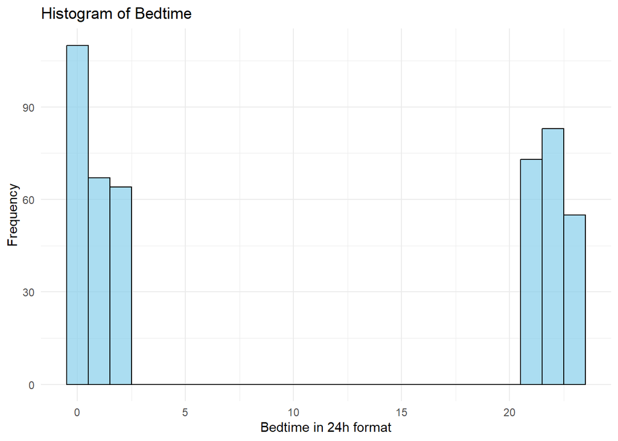

```r
library(ggplot2)

ggplot(data, aes(x = Bedtime.number)) +
  geom_histogram(binwidth = 1, fill = "skyblue", color = "black", alpha = 0.7) +
  labs(x = "Bedtime in 24h format", y = "Frequency") +
  ggtitle("Histogram of Bedtime") +
  theme_minimal()
```

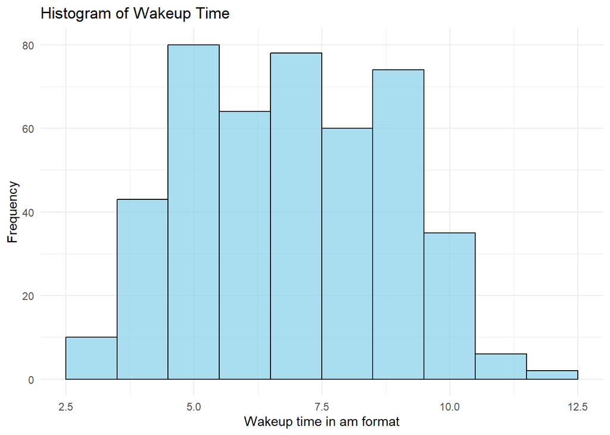

```r
library(ggplot2)

ggplot(data, aes(x = Wakeup.time.number)) +
  geom_histogram(binwidth = 1, fill = "skyblue", color = "black", alpha = 0.7) +
  labs(x = "Wakeup time in am format", y = "Frequency") +
  ggtitle("Histogram of Wakeup Time") +
  theme_minimal()
```

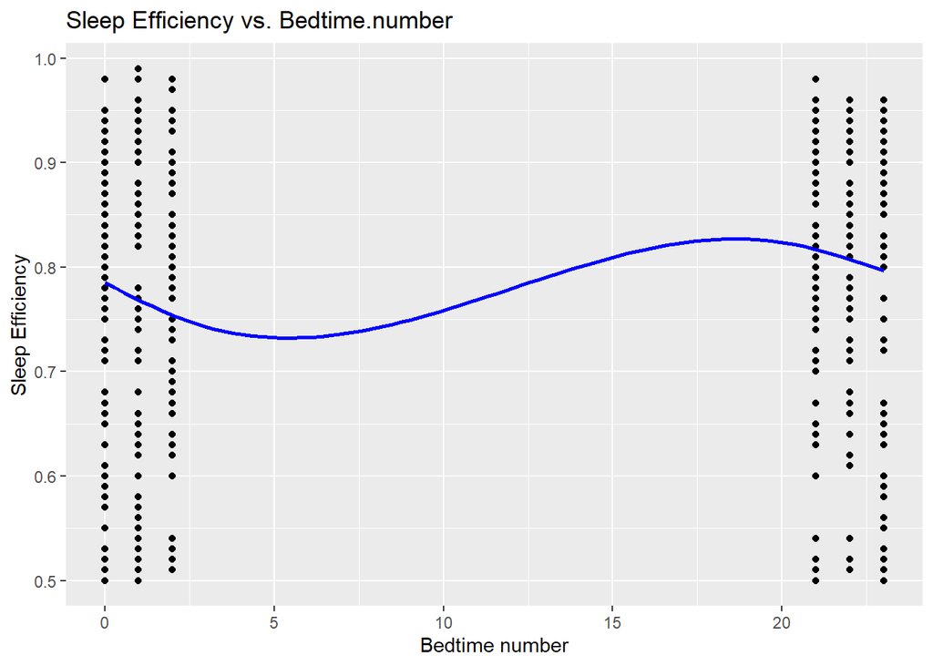

```r
ggplot(data, aes(x = Bedtime.number, y = Sleep.efficiency)) +
  geom_point() +
  geom_smooth(method = "loess", se = FALSE, color = "blue") +  # Add loess smooth line
  #facet_wrap(~Bedtime.number, scales = "free") +  # Facet by Bedtime.number
  labs(
    title = "Sleep Efficiency vs. Bedtime.number",
    x = "Bedtime number",
    y = "Sleep Efficiency"
  )
```

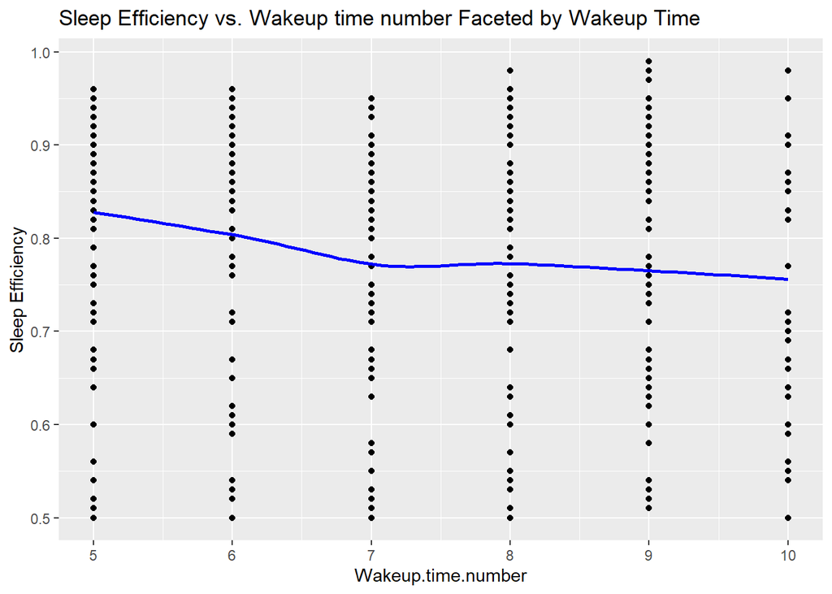

```r
selected_wake_times <- c(5,6, 7, 8, 9,10)
subset_data <- subset(data, Wakeup.time.number %in% selected_wake_times)
ggplot(subset_data, aes(x = Wakeup.time.number, y = Sleep.efficiency)) +
  geom_point() +
  geom_smooth(method = "loess", se = FALSE, color = "blue") +  # Add loess smooth line
  #facet_grid(~ Wakeup.time.number, scales = "free", space = "free") +  # Facet only by Wakeup.time.number
  labs(
    title = "Sleep Efficiency vs. Wakeup time number Faceted by Wakeup Time",
    x = "Wakeup.time.number",
    y = "Sleep Efficiency"
  )
```

```r
data$Sleep.efficiency = ifelse(data$Sleep.efficiency > 0.8 , 1, 0)
```

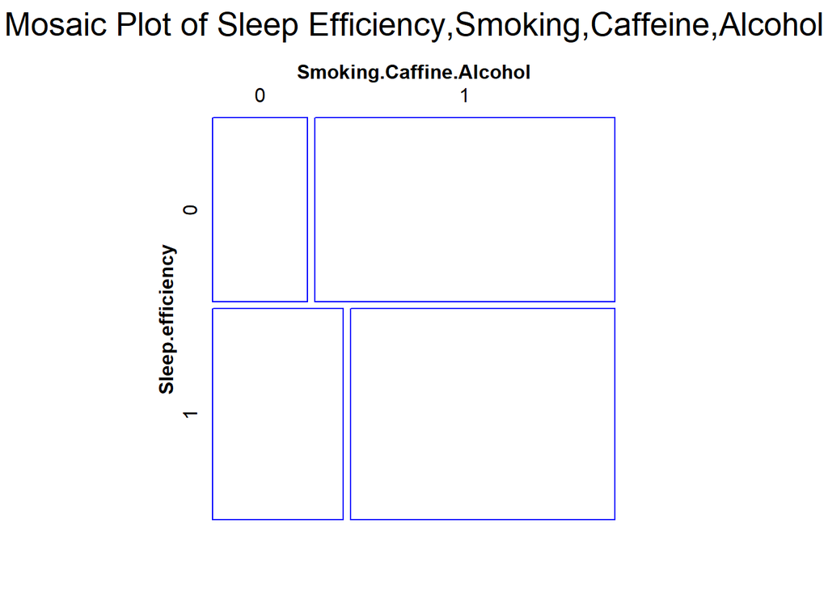

```r
mosaic_plot <- mosaic(~ Sleep.efficiency + Smoking.Caffine.Alcohol, data,
                      gp = gpar(col = "blue", fontsize = 12),
                      main = "Mosaic Plot of Sleep Efficiency,Smoking,Caffeine,Alcohol",
                      xlab = "Smoking, Caffeine, Alcohol",
                      ylab = "Sleep Efficiency",
                      col = c("red", "green"))  # Set custom colors
```

```r
print(mosaic_plot)
```

```
##                  Smoking.Caffine.Alcohol   0   1
## Sleep.efficiency
## 0                                         48 152
## 1                                         76 154
```

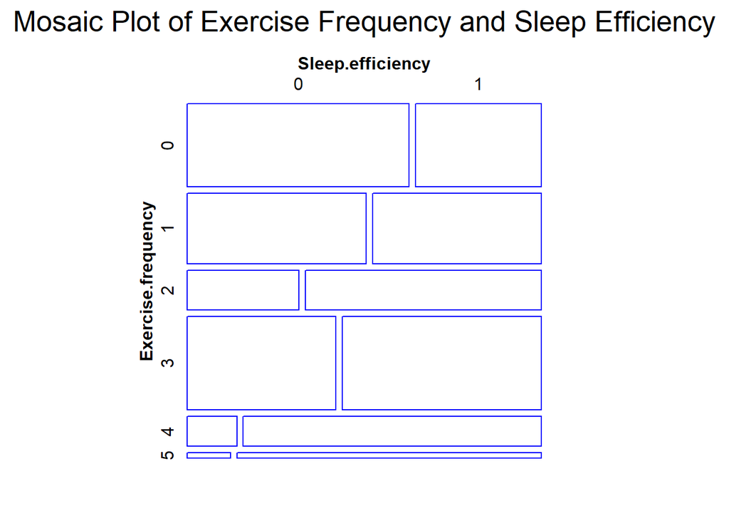

```r
mosaic_plot <- mosaic(~ Exercise.frequency + Sleep.efficiency, data,
                      gp = gpar(col = "blue", fontsize = 12),
                      main = "Mosaic Plot of Exercise Frequency and Sleep Efficiency",
                      xlab = "Exercise Frequency",
                      ylab = "Sleep Efficiency",
                      col = c("red", "green"))
```

```r
print(mosaic_plot)
```

```
##                    Sleep.efficiency  0  1
## Exercise.frequency
## 0                                   74 42
## 1                                   51 48
## 2                                   18 38
## 3                                   56 75
## 4                                    6 36
## 5                                    1  7
```